# **How Economic Stress Shapes Musical Taste in the United States**

Students: Hoang Dieu Linh Nguyen, Tri Huynh

**Project Pages**

Project Website: https://evelynnguyenh.github.io

Project Repository Page: https://github.com/evelynnguyenh/evelynnguyenh.github.io

## **Project Information**

### **About This Project:**

This project investigates whether economic recessions in the United States are associated with measurable shifts in the emotional characteristics of popular music. Using Billboard chart data, Spotify audio features, and federal economic indicators, we analyze four decades of American music to determine whether the music people listen to reflects the economic climate they are living through and if we can use music trends as personal recession indicators.

### **Research Questions:**

**Primary Question:** Are economic recessions in the United States associated with measurable shifts in the tone of popular music?

**Secondary Questions:**

1. Which audio features are most sensitive to economic conditions?
2. Does the degree of economic stress (measured continuously by the Sahm indicator) correlate with shifts in musical positivity?
3. Does genre distribution on the Billboard charts shift during recession periods?

### **Background:**

Music has long been considered a reflection of collective mood. The concept of "recession pop," the idea that economic hardship shapes musical taste at a societal level, has been discussed in popular culture but rarely examined rigorously with data.

Both of us listen to music extensively and have noticed that the music we gravitate toward shifts significantly across different phases of our lives, during stressful periods, celebratory ones, and everything in between. This made us wonder: does the same pattern hold at a macro level? Does an entire nation's musical taste shift in response to economic hardship?

### **Project Datasets:**

**Dataset 1: Billboard Hot 100** Source: https://www.kaggle.com/datasets/dhruvildave/billboard-the-hot-100-songs

The Billboard Hot 100 is the music industry standard for measuring song popularity in the United States, compiled weekly using a combination of digital sales, radio airplay, and streaming data. It is the correct dataset for this project because it captures what Americans were actually listening to at any given point in time, making it our measure of collective musical taste. The dataset spans 1958 to 2021, covering all major economic recessions in our analysis window.

**Dataset 2: Spotify Tracks Dataset 1921-2020** Source: https://www.kaggle.com/datasets/yamaerenay/spotify-dataset-19212020-600k-tracks

This dataset provides audio features for over 600,000 tracks sourced directly from Spotify's API, including valence (emotional positivity), energy (intensity), danceability, and acousticness. These features give us a quantitative measure of the emotional tone of each song, which is the core of our analysis. Without this dataset, we would have no way to objectively measure whether popular music sounds sadder or more energetic during recessions.

**Dataset 3: GDP-Based Recession Indicator (FRED)** Source: https://fred.stlouisfed.org/series/JHDUSRGDPBR

Published by the Federal Reserve Bank of St. Louis, this indicator marks each quarter as a recession (1) or non-recession (0) based on GDP data. It serves as our primary binary classification of economic conditions, allowing us to directly compare audio features between recession and non-recession periods. As a federal government source, it is the most authoritative and widely accepted measure of recession periods in the United States.

**Dataset 4: Real-Time Sahm Rule Recession Indicator (FRED)** Source: https://fred.stlouisfed.org/series/SAHMREALTIME

Developed by economist Claudia Sahm, this indicator measures economic stress as a continuous variable based on unemployment rate changes, rather than a binary flag. We include it alongside the GDP-based indicator because it captures the degree of economic hardship rather than just its presence or absence. The two indicators also complement each other because FRED provides the binary classification while Sahm provides the continuous measure of stress severity.

### **Collaboration Plan:**

The team plans to meet in-person twice a week to review progress and align on next steps. Our primary communication channel is text messaging for quick updates between meetings. Work is divided equally and tracked through a shared Google Sheets task list with assigned to-do items. All project files are stored in a shared GitHub repository, which also hosts our GitHub Pages site, and a shared Google Drive folder for any additional resources. The notebook is maintained in Google Colab, with us coordinating over text before editing to avoid conflicts.

### **ETL (Extraction, Transform, and Load)**

First, we will load in the libraries we'll be using for this tutorial.

```python
# Core libraries
import pandas as pd
import numpy as np
import re
import ast
from scipy import stats

# Visualization
import matplotlib.pyplot as plt
import seaborn as sns
import matplotlib.patches as mpatches
```

#### **Loading the Datasets**

We load all four datasets directly from our GitHub repository using their raw URLs, making the notebook reproducible for anyone without needing local file access.

```python
# Load the datasets
songs = pd.read_csv('https://media.githubusercontent.com/media/evelynnguyenh/evelynnguyenh.github.io/refs/heads/main/songs.csv')
fed_recession = pd.read_csv('https://raw.githubusercontent.com/evelynnguyenh/evelynnguyenh.github.io/refs/heads/main/recession_data.csv')
billboard = pd.read_csv('https://raw.githubusercontent.com/evelynnguyenh/evelynnguyenh.github.io/refs/heads/main/charts.csv')
sahm = pd.read_csv('https://raw.githubusercontent.com/evelynnguyenh/evelynnguyenh.github.io/refs/heads/main/SAHMREALTIME.csv')
```

#### [Billboard Top 100](https://www.kaggle.com/datasets/dhruvildave/billboard-the-hot-100-songs)

The Hot 100 is compiled weekly by Billboard magazine using a combination of digital song sales, radio airplay, and streaming data across the United States. Through this dataset, we have a comprehensive picture of trending songs throughout different time periods.

Let's look at this dataset and examine its structure.

```python
billboard.head()
```

|  | date | rank | song | artist | last-week | peak-rank | weeks-on-board |
| --- | --- | --- | --- | --- | --- | --- | --- |
| 0 | 2021-11-06 | 1 | Easy On Me | Adele | 1.0 | 1 | 3 |
| 1 | 2021-11-06 | 2 | Stay | The Kid LAROI & Justin Bieber | 2.0 | 1 | 16 |
| 2 | 2021-11-06 | 3 | Industry Baby | Lil Nas X & Jack Harlow | 3.0 | 1 | 14 |
| 3 | 2021-11-06 | 4 | Fancy Like | Walker Hayes | 4.0 | 3 | 19 |
| 4 | 2021-11-06 | 5 | Bad Habits | Ed Sheeran | 5.0 | 2 | 18 |

```python
print("Shape:")
billboard.shape
```

```
Shape:
```

```
(330087, 7)
```

We can see that this dataset has 7 columns and 330,087 rows. Now let's look at the dtypes of our columns.

```python
billboard.dtypes
```

|  | 0 |
| --- | --- |
| date | object |
| rank | int64 |
| song | object |
| artist | object |
| last-week | float64 |
| peak-rank | int64 |
| weeks-on-board | int64 |

**dtype:** object

And let's see if there is any missing data in this dataset.

```python
print("Null counts per column:")
billboard.isnull().sum()
```

```
Null counts per column:
```

|  | 0 |
| --- | --- |
| date | 0 |
| rank | 0 |
| song | 0 |
| artist | 0 |
| last-week | 32312 |
| peak-rank | 0 |
| weeks-on-board | 0 |

**dtype:** int64

We can make some observations about this dataset:

- Each row represents a single song's appearance on the Billboard Hot 100 for a specific week, giving us 330,087 weekly chart entries in total.
- The `date` column is stored as a string object rather than a datetime64 dtype, which we will need to convert to the correct dtype.
- The `last-week` column contains 32,312 NaN values. This indicates that those songs were not on the chart the previous week, meaning it is a new entry.
- As a result of those NaNs, `last-week` is stored as float64 (e.g. 1.0, 2.0) instead of an integer.
- Column names use hyphens (`last-week`, `peak-rank`, `weeks-on-board`), which can cause errors so we will rename them to use underscores.
- The dataset is already tidy with one row per observation, one column per variable, so no restructuring is needed.

Convert the dtype of `date`

```python
# Convert date from string to datetime
billboard['date'] = pd.to_datetime(billboard['date'])

# Verify that it worked
billboard['date'].dtype
billboard['date'].head()
```

|  | date |
| --- | --- |
| 0 | 2021-11-06 |
| 1 | 2021-11-06 |
| 2 | 2021-11-06 |
| 3 | 2021-11-06 |
| 4 | 2021-11-06 |

**dtype:** datetime64[ns]

Now let's rename columns to use an underscore instead of hyphen. Then, we convert the dtype from float64 to Int64 since rank values should be whole numbers, and Int64 also supports NaN values. We want to keep NaN here because it's a meaningful value which indicates a song's first appearance on the chart.

```python
# Rename hyphen to underscore
billboard = billboard.rename(columns={
    'last-week': 'last_week',
    'peak-rank': 'peak_rank',
    'weeks-on-board': 'weeks_on_board'
})

# Convert last_week from float64 to nullable integer
# Int64 (capital I) supports NaN, regular int64 does not
billboard['last_week'] = billboard['last_week'].astype('Int64')

# Verify
billboard.dtypes
```

|  | 0 |
| --- | --- |
| date | datetime64[ns] |
| rank | int64 |
| song | object |
| artist | object |
| last_week | Int64 |
| peak_rank | int64 |
| weeks_on_board | int64 |

**dtype:** object

One design choice we have decided on is to keep repeated weekly Billboard appearances rather than deduplicating songs. This means a song that remains on the chart for many weeks contributes more observations than a song that appears only once. We treat this as intentional because repeated chart appearances reflect sustained popularity and exposure. In other words, each unit of observation in this dataset (and our merged dataset later) is not a unique song, but a song-week chart appearance.

However, this also means that long-running hits receive more weight in the analysis. Our results should therefore be interpreted as trends in Billboard chart exposure, not simply trends across unique songs.

#### [Spotify Tracks Dataset 1921-2020](https://www.kaggle.com/datasets/yamaerenay/spotify-dataset-19212020-600k-tracks)

The Spotify Tracks Dataset contains audio features for over 600,000 tracks sourced from Spotify's API, spanning 1921 to 2020. Each row represents one track and includes quantitative measures of emotional tone such as valence (positivity), energy (intensity), danceability, and acousticness, alongside metadata like genre, popularity, and artist information.

Now let's examine this dataset as we did with the billboard dataset.

```python
songs.head()
```

|  | id | name | album_name | artists | danceability | energy | key | loudness | mode | speechiness | ... | tempo | duration_ms | lyrics | year | genre | popularity | total_artist_followers | avg_artist_popularity | artist_ids | niche_genres |
| --- | --- | --- | --- | --- | --- | --- | --- | --- | --- | --- | --- | --- | --- | --- | --- | --- | --- | --- | --- | --- | --- |
| 0 | 0Prct5TDjAnEgIqbxcldY9 | ! | UNDEN!ABLE | ["HELLYEAH"] | 0.415 | 0.605 | 7 | -11.157 | 1 | 0.0575 | ... | 100.059 | 79500 | He said he came from Jamaica,\nhe owned a coup... | 2016 | Rock | 0 | 769490 | 52.0 | ["4hxDvVq5t8ebPYPdBl1F9f"] | ["groove metal", "metal"] |
| 1 | 2ASl4wirkeYm3OWZxXKYuq | !! | Childhood Dreams | ["Yxngxr1"] | 0.788 | 0.648 | 7 | -9.135 | 0 | 0.3150 | ... | 79.998 | 114000 | Fuck the bitch, now she running with my kids\n... | 2019 | Hip-Hop | 29 | 143628 | 45.0 | ["2jwRHcdgkRhelYEMqndDKe"] | [] |
| 2 | 5tA3ImW310llKo8EMBj2Ga | !!Noble Stabbings!! | Situationist Comedy | ["Dillinger Four"] | 0.171 | 0.957 | 2 | -5.749 | 1 | 0.1490 | ... | 175.317 | 197400 | You like to stand on the other side\nPoint and... | 2002 | Rock | 0 | 36619 | 35.0 | ["4YAN46l70QV0PGXlMg0iHi"] | ["melodic hardcore", "pop punk", "punk", "skat... |
| 3 | 0fROT4kK5oTm8xO8PX6EJF | !I'll Be Back! | !I'll Be Back! | ["Ril\u00e8s"] | 0.823 | 0.612 | 1 | -7.767 | 1 | 0.2480 | ... | 142.959 | 178533 | It's been a while, shit, I missed the rehab, p... | 2018 | Hip-Hop | 43 | 929303 | 63.0 | ["6pdcQa7by8IKuoVXvgknlI"] | ["french rap"] |
| 4 | 1xBFhv5faebv3mmwxx7DnS | !Lost! | !Lost! | ["Ril\u00e8s"] | 0.729 | 0.552 | 7 | -8.562 | 0 | 0.0650 | ... | 86.103 | 186197 | I would like to give you all my time\nI would ... | 2018 | Hip-Hop | 0 | 929303 | 63.0 | ["6pdcQa7by8IKuoVXvgknlI"] | ["french rap"] |

5 rows × 24 columns

```python
print("Shape:")
songs.shape
```

```
Shape:
```

```
(550622, 24)
```

```python
songs.dtypes
```

|  | 0 |
| --- | --- |
| id | object |
| name | object |
| album_name | object |
| artists | object |
| danceability | float64 |
| energy | float64 |
| key | int64 |
| loudness | float64 |
| mode | int64 |
| speechiness | float64 |
| acousticness | float64 |
| instrumentalness | float64 |
| liveness | float64 |
| valence | float64 |
| tempo | float64 |
| duration_ms | int64 |
| lyrics | object |
| year | int64 |
| genre | object |
| popularity | int64 |
| total_artist_followers | int64 |
| avg_artist_popularity | float64 |
| artist_ids | object |
| niche_genres | object |

**dtype:** object

The Spotify dataset is clean with no missing values in the audio feature columns. However, at 550,622 rows it is significantly larger than what we need. Many columns are not relevant to our research question as we only need the audio features (valence, energy, danceability, acousticness), the song name and artist for joining, and genre for our genre analysis.

We drop all unused columns to reduce memory usage and simplify the dataset. We also check for duplicate songs since having multiple entries for the same song could introduce bias in the merge.

```python
# Drop columns not needed for analysis
spotify_cols_to_drop = [
    'id', 'album_name', 'artist_ids', 'niche_genres', 'popularity', 'total_artist_followers', 'avg_artist_popularity', 'artist_ids', 'niche_genres',  # metadata not used
    'lyrics',  # no text analysis planned
    'key', 'mode', 'speechiness', 'liveness',  # audio features we don't plan to use in our analysis
    'instrumentalness', 'loudness', 'tempo', 'duration_ms'  # not relevant to research question
]
songs = songs.drop(columns=spotify_cols_to_drop)
# Check for duplicates on song name and artists
duplicates = songs.duplicated(subset=['name', 'artists']).sum()
print(f"Duplicate songs: {duplicates}")
```

```
Duplicate songs: 73057
```

We find 73,057 duplicate song-artist pairs in the Spotify dataset. These likely represent the same song appearing multiple times under different albums, versions, or releases. Keeping duplicates would cause one Billboard song to match multiple Spotify entries during the merge, inflating our row count and introducing inconsistent audio features for the same song. We drop duplicates keeping only the first occurrence.

```python
# Drop duplicate song-artist pairs, keep first occurrence
before = len(songs)
songs = songs.drop_duplicates(subset=['name', 'artists'])
after = len(songs)

print(f"Shape after dropping duplicates: {songs.shape}")
print(f"Duplicates removed: {before - after}")
```

```
Shape after dropping duplicates: (477565, 8)
Duplicates removed: 73057
```

This is our dataset after dropping columns that we won't use and also removing duplicates.

```python
songs.head()
```

|  | name | artists | danceability | energy | acousticness | valence | year | genre |
| --- | --- | --- | --- | --- | --- | --- | --- | --- |
| 0 | ! | ["HELLYEAH"] | 0.415 | 0.605 | 0.001160 | 0.193 | 2016 | Rock |
| 1 | !! | ["Yxngxr1"] | 0.788 | 0.648 | 0.900000 | 0.287 | 2019 | Hip-Hop |
| 2 | !!Noble Stabbings!! | ["Dillinger Four"] | 0.171 | 0.957 | 0.000029 | 0.349 | 2002 | Rock |
| 3 | !I'll Be Back! | ["Ril\u00e8s"] | 0.823 | 0.612 | 0.168000 | 0.688 | 2018 | Hip-Hop |
| 4 | !Lost! | ["Ril\u00e8s"] | 0.729 | 0.552 | 0.183000 | 0.380 | 2018 | Hip-Hop |

```python
songs.shape
```

```
(477565, 8)
```

477,565 rows and 8 columns! A significant drop from our initial 24 columns and 550,622 rows.

#### [GDP-Based Recession Indicator (FRED)](https://fred.stlouisfed.org/series/JHDUSRGDPBR)

The GDP-Based Recession Indicator is published quarterly by the Federal Reserve Bank of St. Louis. Each row represents one quarter and is labeled as either a recession (1) or non-recession (0) based on real GDP data. The indicator covers the period from 1967 onwards, giving us full coverage of our 1980-2020 analysis window.

```python
# Preview FRED recession indicator
fed_recession.head()
```

|  | observation_date | JHDUSRGDPBR |
| --- | --- | --- |
| 0 | 1967-10-01 | 0 |
| 1 | 1968-01-01 | 0 |
| 2 | 1968-04-01 | 0 |
| 3 | 1968-07-01 | 0 |
| 4 | 1968-10-01 | 0 |

```python
fed_recession.shape
```

```
(232, 2)
```

Next, we'll check the data types to see how pandas parsed our dates and economic indicators.

```python
fed_recession.dtypes
```

|  | 0 |
| --- | --- |
| observation_date | object |
| JHDUSRGDPBR | int64 |

**dtype:** object

The GDP-Based Recession Indicator is published quarterly by the Federal Reserve Bank of St. Louis. Each row represents one quarter and is labeled as either a recession (1) or non-recession (0) based on real GDP data. The indicator covers the period from 1967 onwards, giving us full coverage of our 1980-2020 analysis window.

This dataset requires minimal cleaning. The second column is named JHDUSRGDPBR, which is the Federal Reserve's internal series code and is not human-readable. We rename it to "recession" for clarity. Since the Billboard data is weekly and the recession indicator is quarterly, we cannot join them directly on date. Instead, we derive a year-quarter key (e.g. "2008-Q3") from both datasets and join on that key. This maps every weekly Billboard chart appearance to the recession status of the quarter it falls in, allowing us to label each song-week observation as occurring during a recession or not.

```python
# convert FRED date
fed_recession['observation_date'] = pd.to_datetime(fed_recession['observation_date'])

# derive year + quarter
fed_recession['year'] = fed_recession['observation_date'].dt.year
fed_recession['quarter'] = fed_recession['observation_date'].dt.quarter

fed_recession['year_quarter'] = (
    fed_recession['year'].astype(str) + '-Q' + fed_recession['quarter'].astype(str)
)

# rename recession column
fed_recession = fed_recession.rename(columns={'JHDUSRGDPBR': 'recession'})

fed_recession.head()
```

|  | observation_date | recession | year | quarter | year_quarter |
| --- | --- | --- | --- | --- | --- |
| 0 | 1967-10-01 | 0 | 1967 | 4 | 1967-Q4 |
| 1 | 1968-01-01 | 0 | 1968 | 1 | 1968-Q1 |
| 2 | 1968-04-01 | 0 | 1968 | 2 | 1968-Q2 |
| 3 | 1968-07-01 | 0 | 1968 | 3 | 1968-Q3 |
| 4 | 1968-10-01 | 0 | 1968 | 4 | 1968-Q4 |

#### [Real-time Sahm Rule Recession Indicator](https://fred.stlouisfed.org/series/SAHMREALTIME)

The Real-Time Sahm Rule Recession Indicator is also published by the Federal Reserve Bank of St. Louis. Unlike the binary FRED indicator, it provides a continuous monthly measure of economic stress based on changes in the unemployment rate. A value above 0.5 has historically signaled the start of a recession with high accuracy.

Let's look at the dataset.

```python
sahm.head()
```

|  | observation_date | SAHMREALTIME |
| --- | --- | --- |
| 0 | 1959-12-01 | 0.77 |
| 1 | 1960-01-01 | 0.50 |
| 2 | 1960-02-01 | 0.13 |
| 3 | 1960-03-01 | 0.10 |
| 4 | 1960-04-01 | 0.03 |

```python
sahm.dtypes
```

|  | 0 |
| --- | --- |
| observation_date | object |
| SAHMREALTIME | float64 |

**dtype:** object

The dataset contains 796 observations with two columns: `observation_date` and SAHMREALTIME. The `SAHMREALTIME` column is the Federal Reserve's internal series code so we will rename it to "sahm" for better clarity. `observation_date` is also currently stored as an object and needs to be converted to datetime64 before we can process it.

Since the Billboard data is weekly and Sahm is monthly, we will derive a year-month key (e.g. "2008-09") from both datasets and join on that key. This will map every weekly Billboard chart appearance to the economic stress level of the month it falls in.

```python
# Convert observation_date to datetime
sahm['observation_date'] = pd.to_datetime(sahm['observation_date'])

# Rename SAHMREALTIME to sahm for clarity
sahm = sahm.rename(columns={'SAHMREALTIME': 'sahm'})

# Derive year_month key for joining
sahm['year_month'] = sahm['observation_date'].dt.to_period('M').astype(str)

# Verify
print(sahm.dtypes)
print()
sahm.head()
```

```
observation_date    datetime64[ns]
sahm                       float64
year_month                  object
dtype: object
```

|  | observation_date | sahm | year_month |
| --- | --- | --- | --- |
| 0 | 1959-12-01 | 0.77 | 1959-12 |
| 1 | 1960-01-01 | 0.50 | 1960-01 |
| 2 | 1960-02-01 | 0.13 | 1960-02 |
| 3 | 1960-03-01 | 0.10 | 1960-03 |
| 4 | 1960-04-01 | 0.03 | 1960-04 |

#### **Merge the Datasets**

The Billboard and Spotify datasets do not share a direct common identifier, so songs must be matched using song title and artist name.

Since raw text values often contain formatting differences such as punctuation, capitalization, featured artists, or multiple artist listings, we standardize both fields before merging:

- clean_str() converts text to lowercase and removes non-alphanumeric characters.
- get_first_artist() extracts the first artist from Spotify's list-formatted artist field.
- get_first_billboard_artist() isolates the primary artist from Billboard entries that contain "feat." or "featuring." phrases before cleaning.

We apply these functions to create temporary cleaned columns (song_clean, artist_clean) on both datasets, then perform a left join on these two fields. A left join preserves all Billboard chart observations while attaching Spotify audio features whenever a match is found.

```python
# clean_str: this function normalizes text for matching by lowercasing and removing
# all non-alphanumeric characters (spaces, punctuation, special chars)
# For example, "Lil Nas X!" will become "lilnasx"
def clean_str(s):
    s = str(s).lower()
    s = re.sub(r'[^a-z0-9]', '', s)
    return s

# get_first_artist: The 600K Spotify dataaset stores artists as a string-formatted list
# e.g. '["Drake", "Future"]' -- we convert it to an actual list and
# grab only the first (lead) artist to match against Billboard
def get_first_artist(artist_str):
    try:
        return ast.literal_eval(artist_str)[0]  # converts string to list, grabs first
    except:
        return artist_str  # fallback if parsing fails

# get_first_billboard_artist: Billboard lists multiple artists separated
# by "&", "feat.", "ft.", or "featuring" -- we split on any of these
# and take only the lead artist before cleaning
# e.g. "Lil Nas X & Jack Harlow" -> "Lil Nas X"
def get_first_billboard_artist(artist_str):
    return re.split(r'&|feat\.|ft\.|featuring', str(artist_str), flags=re.IGNORECASE)[0].strip()

# Create temporary copies so original dataframes remain unchanged
# Add cleaned song and artist columns used only for matching
billboard_temp = billboard.copy()
billboard_temp['song_clean'] = billboard['song'].apply(clean_str)
billboard_temp['artist_clean'] = billboard['artist'].apply(get_first_billboard_artist).apply(clean_str)

songs_temp = songs.copy()
songs_temp['song_clean'] = songs['name'].apply(clean_str)  # Spotify uses 'name' not 'song'
songs_temp['artist_clean'] = songs['artists'].apply(get_first_artist).apply(clean_str)

# Left join: keeps all Billboard rows, attaches Spotify features where
# a match is found on both cleaned song title and cleaned artist name
# Rows with no match receive NaN for all Spotify columns
merged = billboard_temp.merge(songs_temp, on=['song_clean', 'artist_clean'], how='left')
merged.head()
```

|  | date | rank | song | artist | last_week | peak_rank | weeks_on_board | song_clean | artist_clean | name | artists | danceability | energy | acousticness | valence | year | genre |
| --- | --- | --- | --- | --- | --- | --- | --- | --- | --- | --- | --- | --- | --- | --- | --- | --- | --- |
| 0 | 2021-11-06 | 1 | Easy On Me | Adele | 1 | 1 | 3 | easyonme | adele | Easy On Me | ["Adele"] | 0.604 | 0.366 | 0.5780 | 0.130 | 2021.0 | Pop |
| 1 | 2021-11-06 | 2 | Stay | The Kid LAROI & Justin Bieber | 2 | 1 | 16 | stay | thekidlaroi | NaN | NaN | NaN | NaN | NaN | NaN | NaN | NaN |
| 2 | 2021-11-06 | 3 | Industry Baby | Lil Nas X & Jack Harlow | 3 | 1 | 14 | industrybaby | lilnasx | NaN | NaN | NaN | NaN | NaN | NaN | NaN | NaN |
| 3 | 2021-11-06 | 4 | Fancy Like | Walker Hayes | 4 | 3 | 19 | fancylike | walkerhayes | Fancy Like | ["Walker Hayes"] | 0.649 | 0.760 | 0.1140 | 0.843 | 2021.0 | Country |
| 4 | 2021-11-06 | 5 | Bad Habits | Ed Sheeran | 5 | 2 | 18 | badhabits | edsheeran | Bad Habits | ["Ed Sheeran"] | 0.807 | 0.893 | 0.0451 | 0.537 | 2021.0 | Pop |

Finally, we calculate the match rate using the valence as a non-null valence value that indicates a successful Spotify match. This provides a useful measure of merge quality.

```python
# Match rate: valence is NaN only when no Spotify match was found
# so its presence/absence is a reliable proxy for match success
match_rate = merged['valence'].notna().mean()
print(f"Match rate: {match_rate:.1%}")
print(f"Matched songs: {merged['valence'].notna().sum()} / {len(merged)}")
```

```
Match rate: 44.9%
Matched songs: 153501 / 341724
```

Result: 153,501 out of 341,724 Billboard songs were successfully linked to Spotify metadata (match rate: 44.9%).

To understand how Spotify match coverage varies over time, we derive a decade column from the date field and compute the mean valence coverage per decade.

This helps identify which time periods are well-represented in the merged dataset and informs our decision to restrict the analysis to a specific time window.

```python
merged['decade'] = (pd.to_datetime(merged['date']).dt.year // 10) * 10
coverage = merged.groupby('decade')['valence'].apply(lambda x: x.notna().mean()).round(3)
print(coverage)
```

```
decade
1950    0.337
1960    0.329
1970    0.432
1980    0.476
1990    0.447
2000    0.548
2010    0.491
2020    0.397
Name: valence, dtype: float64
```

Coverage rates vary substantially across decades, ranging from 32.9% in the 1960s to 54.8% in the 2000s. Earlier decades before 1980 generally have weaker match rates, falling between 33% and 43%.

The Spotify match rate is 44.9%, meaning that slightly less than half of all Billboard weekly chart observations were successfully matched to Spotify audio features. This is an important limitation of the project. Unmatched songs may differ systematically from matched songs because older tracks, songs with complex artist names, remixes, featured artists, punctuation differences, or songs unavailable in the Spotify dataset are less likely to match successfully.

Because match coverage varies by decade, our final dataset should not be interpreted as the full Billboard Hot 100 population. Instead, our findings apply to the subset of Billboard chart appearances that could be matched to Spotify audio features. This may bias results toward more easily matched, Spotify-represented songs.

Throughout the examined Billboard data, the 1980–2020 period shows stronger and more stable coverage, with rates between 39.7% and 54.8%. For this reason, the 1980–2020 time window is more reliable and will be the primary focus of later analysis.

```python
merged['year'] = pd.to_datetime(merged['date']).dt.year # extract year
merged = merged[(merged['year'] >= 1980) & (merged['year'] <= 2020)] # keep songs between 1980 and 2020
merged = merged.dropna() # drop all rows that couldn't be matched
print(f"Rows remaining: {len(merged)}")
```

```
Rows remaining: 99347
```

Based on coverage analysis, we restrict our dataset to a 1980-2020 time window and drop rows with any remaining null values in a single step. Null values come from Billboard songs that could not be matched to a Spotify entry and therefore have no audio features. This reduces the dataset from 341,724 to 99,347 rows.

We perform Complete Case Analysis because audio features cannot be imputed. There is no reasonable way to estimate what a song's valence or energy would be without Spotify data. Dropping unmatched rows is the only viable option.

The missingness in our dataset is best characterized as Missing at Random (MAR) rather than Missing Completely at Random (MCAR). Coverage varies systematically by decade, meaning older decades have lower match rates because Spotify's database has less historical depth, not because songs are missing randomly. Since missingness depends on an observed variable (decade), this satisfies the MAR definition.

As a result, our analysis represents only Billboard songs that could be matched to Spotify and does not fully represent the complete Billboard chart history. Songs from earlier decades are underrepresented relative to their true prevalence. We acknowledge this limitation and note that findings should be interpreted as applying to the matched subset of charting songs rather than the full population of Billboard hits.

```python
merged['quarter'] = pd.to_datetime(merged['date']).dt.quarter # extract quarter (1–4)
merged['year_quarter'] = merged['year'].astype(str) + '-Q' + merged['quarter'].astype(str) # combine as join key

merged[['date','year_quarter']].head()
```

|  | date | year_quarter |
| --- | --- | --- |
| 4619 | 2020-12-26 | 2020-Q4 |
| 4620 | 2020-12-26 | 2020-Q4 |
| 4621 | 2020-12-26 | 2020-Q4 |
| 4622 | 2020-12-26 | 2020-Q4 |
| 4625 | 2020-12-26 | 2020-Q4 |

To merge the monthly Sahm Rule indicator with the weekly Billboard data, we create a shared `year_month` field from the date column. This lets each Billboard observation inherit the economic stress value for the month in which it appeared.

```python
# JOIN recession indicator first to create final
final = merged.merge(
    fed_recession[['year_quarter', 'recession']],
    on='year_quarter',
    how='left'
)

# Then derive year_month key for joining Sahm indicator
final['year_month'] = pd.to_datetime(final['date']).dt.to_period('M').astype(str)

# Join Sahm indicator
final = final.merge(sahm[['year_month', 'sahm']], on='year_month', how='left')

# Verify
print(final[['valence','energy', 'danceability', 'acousticness', 'recession', 'sahm']].isnull().sum())
print(f"Rows: {len(final)}")
```

```
valence         0
energy          0
danceability    0
acousticness    0
recession       0
sahm            0
dtype: int64
Rows: 99347
```

**Overall, the dataset is now fully prepared for exploratory analysis of how economic stress may relate to changes in popular music features.**

## **EDA (Exploratory Data Analysis)**

**Exploratory Analysis of Popular Music Trends**

"Recession pop" is a term used to describe the dance-pop and electropop sound that emerged during the Great Recession in the United States in the late 2000s to early 2010s. It reflects the idea that economic hardship shapes the kind of music people gravitate toward at a societal level. Our hypothesis is that during recessions, we will see a rise in pop song popularity on the Billboard Hot 100. We start by counting the genres present in our dataset to understand the overall distribution.

```python
print(final['genre'].value_counts())
```

```
genre
Country       21064
Rock          18973
Pop           17907
R&B           16224
Hip-Hop       16116
Electronic     5295
Folk           2300
Jazz            654
Blues           503
Classical       311
Name: count, dtype: int64
```

We can group smaller genres under "Other" to keep the comparison clean.

```python
# Group small genres into Other
top_genres = ['Country', 'Rock', 'Pop', 'Hip-Hop', 'R&B']
final['genre_grouped'] = final['genre'].apply(lambda x: x if x in top_genres else 'Other')
```

Now let's visualize how genre distribution shifts between normal and recession periods.

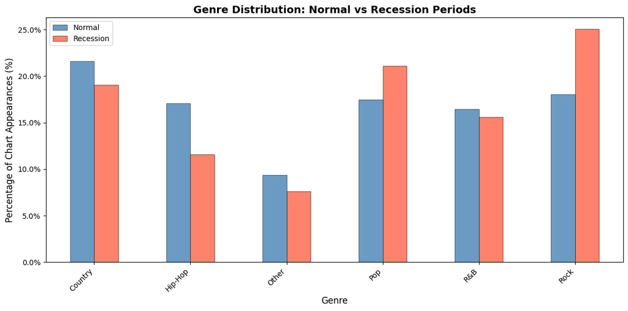

```python
# Count chart appearances for each genre-recession combination,
# then pivot so recession status becomes rows and genres become columns
genre_dist = final.groupby(['recession', 'genre_grouped']).size().unstack()

# Convert raw counts to percentages so genres are comparable across groups
genre_dist = genre_dist.div(genre_dist.sum(axis=1), axis=0) * 100

# Rename index from 0/1 to readable labels
genre_dist.index = ['Normal', 'Recession']

# Plot grouped bar chart with genres on x-axis and recession status as hue
fig, ax = plt.subplots(figsize=(12, 6))
genre_dist.T.plot(kind='bar', ax=ax, color=['steelblue', 'tomato'],
                  alpha=0.8, edgecolor='black', linewidth=0.5)

# Labels and formatting
ax.set_title('Genre Distribution: Normal vs Recession Periods',
             fontsize=14, fontweight='bold')
ax.set_xlabel('Genre', fontsize=12)
ax.set_ylabel('Percentage of Chart Appearances (%)', fontsize=12)
ax.set_xticklabels(ax.get_xticklabels(), rotation=45, ha='right')
ax.legend(['Normal', 'Recession'])

# Format y-axis ticks as percentages
ax.yaxis.set_major_formatter(plt.matplotlib.ticker.FormatStrFormatter('%.1f%%'))

plt.tight_layout()
plt.show()
```

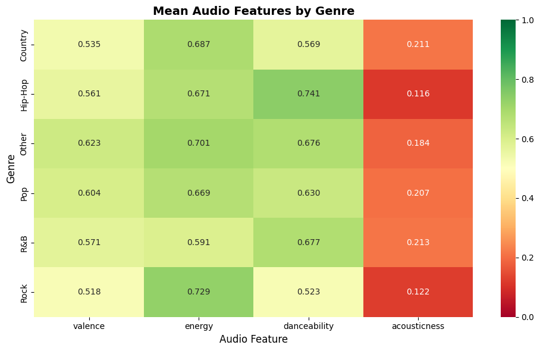

```python
# Compute mean audio features for each genre
genre_features = final.groupby('genre_grouped')[['valence', 'energy', 'danceability', 'acousticness']].mean().round(3)

# Plot heatmap with color scale from 0 to 1 matching Spotify's feature range
fig, ax = plt.subplots(figsize=(10, 6))

sns.heatmap(genre_features,
            annot=True,       # show values in each cell
            fmt='.3f',        # format to 3 decimal places
            cmap='RdYlGn',    # red = low, green = high
            vmin=0, vmax=1,   # fix scale to Spotify's 0-1 range
            ax=ax)

ax.set_title('Mean Audio Features by Genre',
             fontsize=14, fontweight='bold')
ax.set_xlabel('Audio Feature', fontsize=12)
ax.set_ylabel('Genre', fontsize=12)

plt.tight_layout()
plt.show()
```

Rock has the lowest valence of all genres at 0.518, meaning it tends to sound the least emotionally positive. It also has the highest energy at 0.729, which gives it an intense but not necessarily upbeat character. Hip-Hop, which dropped during recessions, has the highest danceability at 0.741. This means the genre shift we observed isn't neutral: when Rock replaces Hip-Hop on the charts, the overall sound becomes less danceable and less positive. This sets up our next question: do we actually see a measurable difference in audio features between recession and normal periods across all songs? The boxplot below compares the distribution of each feature directly.

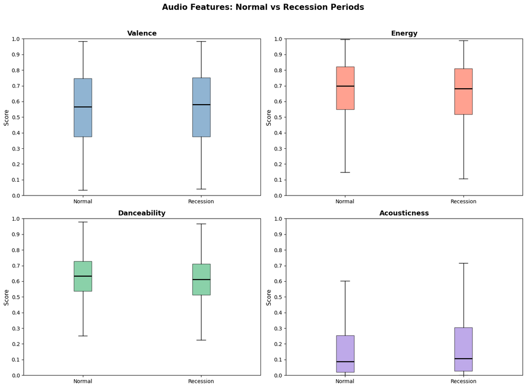

```python
# Define features to plot and their corresponding colors
features = ['valence', 'energy', 'danceability', 'acousticness']
colors = ['steelblue', 'tomato', 'mediumseagreen', 'mediumpurple']

# Create a 2x2 grid of subplots, one per feature
fig, axes = plt.subplots(2, 2, figsize=(14, 10))
axes = axes.flatten()  # flatten to iterate over axes easily

for i, (feature, color) in enumerate(zip(features, colors)):
    # Split data by recession status
    recession_data = final[final['recession'] == 1][feature]
    normal_data = final[final['recession'] == 0][feature]

    # Plot side-by-side boxplots for normal vs recession
    axes[i].boxplot([normal_data, recession_data],
                    tick_labels=['Normal', 'Recession'],
                    patch_artist=True,                              # fill boxes with color
                    boxprops=dict(facecolor=color, alpha=0.6),
                    medianprops=dict(color='black', linewidth=2),
                    showfliers=False)                               # hide outliers for readability

    # Labels and formatting
    axes[i].set_title(feature.capitalize(), fontsize=13, fontweight='bold')
    axes[i].set_ylabel('Score', fontsize=11)
    axes[i].set_ylim(0, 1)
    axes[i].set_yticks(np.arange(0, 1.05, 0.1))

fig.suptitle('Audio Features: Normal vs Recession Periods',
             fontsize=15, fontweight='bold', y=1.02)
plt.tight_layout()
plt.show()
```

Across most features, the distributions between normal and recession periods look nearly identical, suggesting that any recession effect on audio features may be small or masked by other factors. Acousticness is the exception, showing a wider spread during recessions, but this is likely explained by the natural evolution of music technology over our 40-year window rather than economic conditions. Since recessions don't all occur in the same decade, lumping them together obscures long-term trends. To account for this, we look at how audio features have changed year by year.

**Exploratory Analysis of Economic Relationships**

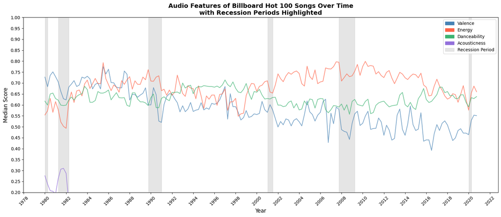

```python
# Define features to plot and their corresponding colors
features = ['valence', 'energy', 'danceability', 'acousticness']
colors = ['steelblue', 'tomato', 'mediumseagreen', 'mediumpurple']

# Get all rows where recession == 1 and find the earliest date per quarter
# This gives us one date anchor per recession quarter for shading
recession_quarters = final[final['recession'] == 1][['year_quarter', 'date']].copy()
recession_quarters['date'] = pd.to_datetime(recession_quarters['date'])
recession_periods = recession_quarters.groupby('year_quarter')['date'].min().reset_index()
recession_periods['date'] = pd.to_datetime(recession_periods['date'])

# Group consecutive recession quarters into continuous shaded blocks
# Recession quarters are about 90 days apart, so we use 100 days as a buffer to group them into one continuous shaded block
recession_dates = sorted(recession_periods['date'].tolist())
blocks = []
if recession_dates:
    start = recession_dates[0]
    end = recession_dates[0]
    for d in recession_dates[1:]:
        if (d - end).days <= 100:
            end = d
        else:
            blocks.append((start, end))
            start = d
            end = d
    blocks.append((start, end))

# Compute median audio features per quarter for smoother trend lines
trend = final.groupby('year_quarter')[features].median().reset_index()

# Convert year_quarter string (e.g. '2008-Q3') to a datetime by mapping
# Q1 -> Jan, Q2 -> Apr, Q3 -> Jul, Q4 -> Oct
trend['year_quarter'] = pd.to_datetime(
    trend['year_quarter'].str.replace(r'-Q(\d)',
    lambda m: f'-{int(m.group(1))*3-2:02d}-01', regex=True)
)
trend = trend.sort_values('year_quarter')

# Plot each audio feature as a line over time
fig, ax = plt.subplots(figsize=(16, 7))

for feature, color in zip(features, colors):
    ax.plot(trend['year_quarter'], trend[feature],
            color=color, linewidth=1.5, label=feature.capitalize(), alpha=0.7)

# Shade each recession block in grey
for start, end in blocks:
    ax.axvspan(start, end, alpha=0.2, color='grey', label='_nolegend_')

# Formatting
ax.set_ylim(0.2, 1.0)
ax.set_yticks(np.arange(0.2, 1.05, 0.05))
ax.xaxis.set_major_locator(plt.matplotlib.dates.YearLocator(2))
ax.xaxis.set_major_formatter(plt.matplotlib.dates.DateFormatter('%Y'))
plt.xticks(rotation=45)

ax.set_title('Audio Features of Billboard Hot 100 Songs Over Time\nwith Recession Periods Highlighted',
             fontsize=14, fontweight='bold')
ax.set_xlabel('Year', fontsize=12)
ax.set_ylabel('Median Score', fontsize=12)

# Build legend manually to include recession shading patch
recession_patch = mpatches.Patch(color='grey', alpha=0.2, label='Recession Period')
ax.legend(handles=[*[mpatches.Patch(color=c, label=f.capitalize())
                     for f, c in zip(features, colors)], recession_patch])

plt.tight_layout()
plt.show()
```

The time series shows two patterns worth separating. In the short term, valence and energy tend to dip at the start of recession periods, which is consistent with our hypothesis. Danceability stays relatively stable throughout, suggesting it is less sensitive to economic conditions. The larger pattern, however, is a long-term decline in valence since 1980 that occurs regardless of recession periods. Music has gotten less positive over four decades, and this trend would confound a simple Normal vs Recession comparison. Acousticness dropped sharply around 1982 and stayed low, which reflects the shift toward electronic production and synth-pop rather than any economic effect. This explains the wider acousticness spread we saw in the boxplot: it is a decades-long technology shift, not a recession pattern.

To formally measure the relationship between audio features and economic conditions, we compute a correlation matrix between all four audio features and both economic indicators.

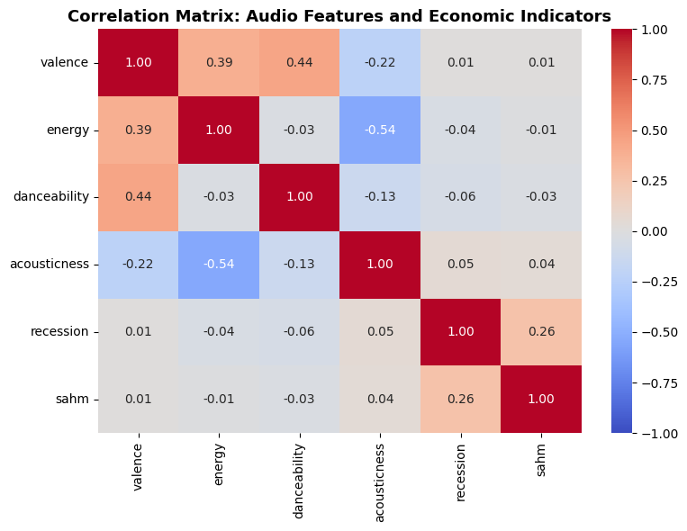

```python
# Select audio features and both economic indicators for correlation analysis
corr_cols = ['valence', 'energy', 'danceability', 'acousticness', 'recession', 'sahm']
corr_matrix = final[corr_cols].corr().round(2)

# Plot heatmap with diverging color scale centered at 0
# red = positive correlation, blue = negative correlation
fig, ax = plt.subplots(figsize=(8, 6))
sns.heatmap(corr_matrix,
            annot=True,       # show correlation values in each cell
            fmt='.2f',        # format to 2 decimal places
            cmap='coolwarm',  # diverging color scale
            center=0,         # white at zero correlation
            vmin=-1, vmax=1,  # fix scale to full correlation range
            ax=ax)

ax.set_title('Correlation Matrix: Audio Features and Economic Indicators',
             fontsize=13, fontweight='bold')

plt.tight_layout()
plt.show()
```

The table below shows the mean, median, and standard deviation of each audio feature grouped by recession status

```python
# Compute mean, median, and standard deviation of each audio feature
# grouped by recession status to compare distributions between the two periods
summary = final.groupby('recession')[['valence', 'energy', 'danceability', 'acousticness']].agg(['mean', 'median', 'std']).round(3)

# Rename index from 0/1 to readable labels
summary.index = ['Normal', 'Recession']
print(summary)
```

```
          valence               energy               danceability         \
             mean median    std   mean median    std         mean median
Normal      0.561  0.567  0.230  0.678  0.698  0.178        0.630  0.633
Recession   0.567  0.580  0.234  0.656  0.683  0.191        0.605  0.612

                 acousticness
             std         mean median    std
Normal     0.140        0.171  0.087  0.203
Recession  0.146        0.201  0.107  0.228
```

Across all four features, the differences between normal and recession periods are small. Energy and danceability are slightly lower during recessions, while acousticness is slightly higher. Valence is nearly unchanged, with only a very small increase during recession periods. The standard deviations are large relative to the differences in means, which suggests high variability within each group and reinforces what we saw in the boxplots.

## **Building A Hypothesis Testing Model**

### **Why Hypothesis Testing?**

We use two-sample z-tests to answer this question with one test per audio feature. Because our dataset has ~99,000 observations, the Central Limit Theorem guarantees the sampling distribution of the mean is normal, so we can use the standard normal distribution (with z-score). The z-test is the right tool here because our goal is inference (checking whether a relationship exists) rather than prediction.

### Our Hypotheses

Before running any test, we define what we are testing. For each audio feature:

- **$H_0$ (Null Hypothesis):** The mean is the **same** during recession and non-recession periods
- **$H_1$ (Alternative Hypothesis):** The mean is **different** during recession and non-recession periods

We use a **two-tailed test** because we are open to the feature going either up or down. We will choose the **significance level $\alpha$ = 0.05**.

| Feature | $H_0$ | $H_1$ |
| --- | --- | --- |
| Valence | $\mu_{recession} = \mu_{normal}$ | $\mu_{recession} \neq \mu_{normal}$ |
| Energy | $\mu_{recession} = \mu_{normal}$ | $\mu_{recession} \neq \mu_{normal}$ |
| Danceability | $\mu_{recession} = \mu_{normal}$ | $\mu_{recession} \neq \mu_{normal}$ |
| Acousticness | $\mu_{recession} = \mu_{normal}$ | $\mu_{recession} \neq \mu_{normal}$ |

### Check Assumptions

The two-sample z-test requires two conditions:

1. **Independence:** the two groups (recession vs. normal) do not overlap. A song entry either charted during a recession quarter or it did not. This condition is fulfilled because recession is defined using a binary indicator, so a Billboard entry will either be in a recession period or not.
2. **Large sample size:** with both groups well above n = 30, the Central Limit Theorem applies. The sampling distribution of the mean is approximately normal regardless of the shape of the raw data. This is what justifies using a z-score instead of a t-statistic.

Let's verify the group sizes:

```python
recession_group = final[final['recession'] == 1]
normal_group    = final[final['recession'] == 0]

print(f"Normal observations:    {len(normal_group):,}")
print(f"Recession observations: {len(recession_group):,}")
```

```
Normal observations:    84,098
Recession observations: 15,249
```

Both groups are much larger than n=30, so the Central Limit Theorem applies.

### Run the Z-Tests

We compute a two-sample z-score for each audio feature using the formula:

$$z = \frac{\bar{x}_{recession} - \bar{x}_{normal}}{\sqrt{\frac{s_{recession}^2}{n_{recession}} + \frac{s_{normal}^2}{n_{normal}}}}$$

The z-score tells us how many standard errors the observed difference is from zero under the null hypothesis. We then convert it to a p-value using the standard normal distribution:

- **z-score:** How far the difference is from zero in standard error units. A z beyond $\pm$1.96 corresponds to p < 0.05.
- **p-value:** The probability of seeing a difference this large if $H_0$ were true (two-tailed). If p < 0.05, we reject $H_0$.

```python
# Audio features we're testing, each getting their own z-test
features = ['valence', 'energy', 'danceability', 'acousticness']

# Print a formatted header row for the results table
print(f"{'Feature':<15} {'Normal Mean':>12} {'Recession Mean':>15} {'Difference':>12} {'z-score':>10} {'p-value':>12} {'Reject H₀':>10}")
print("-" * 90)

# We'll collect each test's results here so we can reuse them in the visualization below
results = []

for feature in features:
    # Slice out just the values for this feature from each economic group
    normal_vals    = normal_group[feature]
    recession_vals = recession_group[feature]

    ### Get sample sizes and means ###
    # n1/n2 are the number of observations in each group
    # Both are >> 30, which is what lets us use the normal distribution (CLT)
    n1, n2       = len(normal_vals), len(recession_vals)
    mean1, mean2 = normal_vals.mean(), recession_vals.mean()

    ### Compute sample standard deviations ###
    # ddof=1 uses Bessel's correction (divides by n-1 instead of n),
    # which gives an unbiased estimate of the population standard deviation
    std1, std2 = normal_vals.std(ddof=1), recession_vals.std(ddof=1)

    ### Compute the standard error of the difference ###
    # This tells us how much the difference in means would vary
    # across repeated samples just due to random chance.
    # Formula: SE = sqrt(s1²/n1 + s2²/n2)
    # We use this instead of a pooled SE because we don't assume equal variances
    se = np.sqrt((std1**2 / n1) + (std2**2 / n2))

    ### Compute the z-score ###
    # z = (observed difference) / (standard error)
    # A z-score of 1.96 or beyond corresponds to p < 0.05 (two-tailed)
    # Positive z means the recession mean is higher; negative means lower
    z_score = (mean2 - mean1) / se

    ### Convert z-score to a two-tailed p-value ###
    # stats.norm.sf(x) = P(Z > x) = the right-tail probability of the standard normal
    # We take abs(z_score) to always start from the right tail,
    # then multiply by 2 to account for both tails (we're testing ≠, not > or <)
    p_value = 2 * stats.norm.sf(abs(z_score))

    # Compute the raw mean difference (recession minus normal)
    # Positive = feature is higher during recessions, negative = lower
    diff = mean2 - mean1

    # Reject null hypothesis if p-value is below our significance threshold of alpha = 0.05
    reject = p_value < 0.05

    # Store all values for this feature so the visualization cell can access them
    results.append({
        'feature':        feature,
        'normal_mean':    mean1,
        'recession_mean': mean2,
        'diff':           diff,
        'z_score':        z_score,
        'p_value':        p_value,
        'reject':         reject,
    })

    print(f"{feature:<15} {mean1:>12.4f} {mean2:>15.4f} {diff:>12.4f} {z_score:>10.3f} {p_value:>12.2e} {'Yes' if reject else 'No':>10}")

# Convert results list to a DataFrame so the visualization cell can look up p-values by feature name
results_df = pd.DataFrame(results)
```

```
Feature          Normal Mean  Recession Mean   Difference    z-score      p-value  Reject H₀
------------------------------------------------------------------------------------------
valence               0.5613          0.5669       0.0056      2.727     6.39e-03        Yes
energy                0.6782          0.6559      -0.0223    -13.381     7.78e-41        Yes
danceability          0.6305          0.6053      -0.0252    -19.739     9.92e-87        Yes
acousticness          0.1710          0.2013       0.0303     15.388     1.96e-53        Yes
```

### Visualize the Results

We visualize the mean of each audio feature for both groups side by side. Error bars show the **95% confidence interval** around each mean, so we can see at a glance whether the two groups overlap.

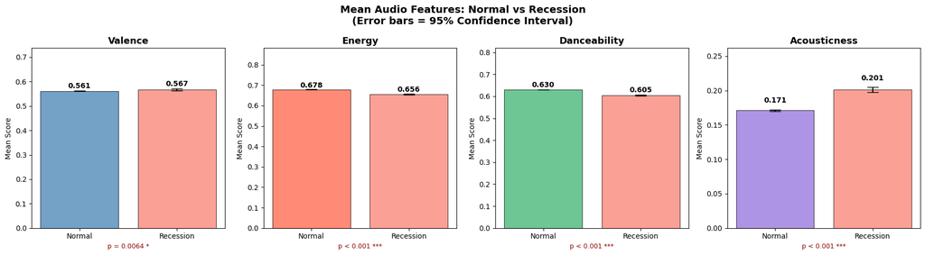

```python
fig, axes = plt.subplots(1, 4, figsize=(18, 5))
colors = ['steelblue', 'tomato', 'mediumseagreen', 'mediumpurple']

for i, (feature, color) in enumerate(zip(features, colors)):
    normal_vals    = normal_group[feature]
    recession_vals = recession_group[feature]

    means  = [normal_vals.mean(), recession_vals.mean()]
    errors = [1.96 * stats.sem(normal_vals), 1.96 * stats.sem(recession_vals)]

    axes[i].bar(['Normal', 'Recession'], means,
                color=[color, 'salmon'], alpha=0.75,
                yerr=errors, capsize=8,
                edgecolor='black', linewidth=0.8)

    axes[i].set_title(feature.capitalize(), fontsize=13, fontweight='bold')
    axes[i].set_ylabel('Mean Score')
    axes[i].set_ylim(0, max(means) * 1.3)

    # Label each bar with its mean value
    for j, (mean, err) in enumerate(zip(means, errors)):
        axes[i].text(j, mean + err + 0.01, f'{mean:.3f}',
                     ha='center', fontsize=10, fontweight='bold')

    # Show p-value below the feature name
    row = results_df[results_df['feature'] == feature].iloc[0]
    p   = row['p_value']
    p_label = "p < 0.001 ***" if p < 0.001 else f"p = {p:.4f} *" if p < 0.05 else f"p = {p:.4f}"
    axes[i].set_xlabel(p_label, fontsize=9,
                       color='darkred' if p < 0.05 else 'gray')

fig.suptitle('Mean Audio Features: Normal vs Recession\n(Error bars = 95% Confidence Interval)',
             fontsize=14, fontweight='bold')
plt.tight_layout()
plt.show()
```

### Interpret the Results

#### **What the z-scores and p-values tell us**

All four features have p-values well below $\alpha = 0.05$, so we **reject the null hypothesis for every feature**. The differences between recession and non-recession periods are statistically significant and unlikely to be due to chance.

A z-score beyond $\pm 1.96$ corresponds to $p < 0.05$. All four features exceed this threshold, with three exceeding it by an enormous margin.

#### **But how meaningful are the differences?**

This is where we need to be careful. With ~99,000 observations, our z-test has enormous **statistical power** and can detect even tiny differences as significant. A p-value tells us whether a difference exists, not whether it matters in practice.

Looking at the actual differences:

- **Danceability** drops by about 0.025 during recessions (from 0.6305 to 0.6053)
- **Energy** drops by about 0.022 (from 0.6782 to 0.6559)
- **Acousticness** rises by about 0.030 (from 0.1710 to 0.2013)
- **Valence** increases very slightly by 0.006 (from 0.5613 to 0.5669)

We have confirmed that these differences are real, however, they are small. On Spotify's 0 to 1 scale, a shift of 0.02 is essentially imperceptible to a listener. The extreme z-scores for the audio features are likely a product of our huge sample size instead of just the size of the effect itself. Valence, despite having the smallest z-score, is actually the most interesting result: even with ~99,000 observations giving us enormous power to detect small effects, the recession signal for valence is relatively weak. This suggests valence may be less sensitive to economic conditions than the other features.

The genre shift we found in EDA, specifically Rock gaining chart share during recessions, is likely a driver of these aggregate differences rather than any dramatic shift in the emotional tone of individual songs.

#### **What this does and does not mean**

What we found: In our matched Billboard-Spotify dataset, recession periods are associated with small but statistically significant differences in audio features. Songs appearing during recession periods are slightly less energetic and less danceable on average, while acousticness is slightly higher. These findings are consistent across all four features at $\alpha = 0.05$.

What we did not find: Evidence that recessions cause these shifts. Many confounding factors exist, including long-term technology trends, demographic changes in who listens to radio, and changes in Billboard's own methodology over the decades covered by this dataset.

Our finding is better described as a statistical association as it does not point out any causation relationships.

## **Conclusion**

### **What We Set Out to Do**

We started this project with a simple question: does the music Americans listen to shift in measurable ways during economic recessions? The idea of "recession pop" gets talked about a lot in popular culture, but we wanted to test it with actual data. Using Billboard chart data from 1980 to 2020, Spotify audio features, and two federal recession indicators from FRED, we built a pipeline that merged weekly chart appearances with quantitative measures of musical tone, then tested whether those measures differed between recession and non-recession periods.

### **What We Found**

The z-tests confirmed that all four audio features, valence, energy, danceability, and acousticness, differ significantly between recession and non-recession periods. Energy and danceability drop slightly during recessions, while acousticness rises. Valence is the most interesting case: it barely moves at all, with a mean difference of only 0.006, and it has the weakest z-score of the four features by far ($z = 2.727$). That's still statistically significant, but given that our dataset has ~99,000 observations and enormous statistical power, the fact that valence barely registers might indicate that emotional positivity in popular music, the feature most directly tied to the idea of songs sounding "sadder" during hard times, is not strongly tied to economic conditions.

That said, we want to be careful about how we frame these findings. The differences are statistically real but practically small. With the scale of the audio features going from 0 to 1, a shift of 0.02 is not something a listener would notice. We think the genre shift we found in EDA, not a dramatic change in how individual songs sound, is probably the main driver of these aggregate differences.

### **Limitations**

There are a few things about how we built this dataset that readers should keep in mind when interpreting our results.

1. The first is our Spotify match rate. Only 44.9% of Billboard weekly chart appearances were successfully matched to a Spotify track. Coverage also varies by decade, which is why we restricted the dataset to 1980 to 2020. Songs that failed to match are likely older, have unusual punctuation or artist formatting, or simply aren't in the Spotify database. This means our final dataset is not a complete picture of the Billboard Hot 100. It skews toward mainstream, well-documented songs, and our results reflect that sample, not the full population of charting music.
2. The second is how we count popularity. Each row in our dataset is a weekly chart appearance, not a unique song. A song that stays on the chart for 20 weeks contributes 20 observations. We did this intentionally because sustained chart presence reflects sustained listening, but it can possibly inflate our effective sample size with correlated observations. The same song's valence score is counted many times over. This is part of why our z-scores are so extreme for energy and danceability.
3. The third is confounding. Recession periods cluster in specific decades, and audio features like valence and acousticness also trend over time independently of recessions. We can't separate the recession effect from broader decade-level shifts in what popular music sounds like.

### **Final Takeaway**

We found that economic recessions are associated with small but statistically significant shifts in the audio features of charting music, particularly in energy, danceability, and acousticness. Valence, the feature most people would point to when talking about music sounding "sadder" during hard times, barely adjusted. We think it indicates that recession pop is more about genre and feel than about songs literally becoming more emotionally negative.

Our project cannot confirm any causal relationships between economic recessions and audio features of charting songs. What we can say is that there is a measurable and consistent pattern that holds up to formal testing.

### **Further Resource**

1. The Sahm Rule: https://www.currentmarketvaluation.com/models/sahm-rule.php
2. Using Spotify data to find the happiest emo song: https://medium.com/analytics-vidhya/using-spotify-data-to-find-the-happiest-emo-song-20e37fdf9eb
3. Recession Pop Is the Playlist of the Year: Defining the Genre: https://www.siriusxmmedia.com/insights/recession-pop-is-the-playlist-of-the-year-defining-the-genre
4. Why is Everything a Recession Indicator? https://cer.econ.columbia.edu/news/why-everything-recession-indicator